# ACM & CAH pour la base des avis de marchés (AM) et les avis de passations de marchés (AA)

# 1 Introduction :

*Ce document a pour but d’expliquer le code “Code_acm_AA&AM.R”. Ce code contient une Analyse des Correspondances Multiples pour plusieurs variables catégorielles des bases des avis de marché et des avis d’attribution.Pour des raisons qui seront expliquées ultérieurement, une classification hiérarchique ascendante des individus par rapport aux nouveaux axes issue de l’ACM.*

# 2 Préparatif :

**Tout d’abord chargeons les librairies utiles et les données:**

```r
library(FactoMineR)
library(factoextra)
```

```r
library(cowplot)

data_TED_CAN_2011_2020_modif <- read.csv("TED-Contract_award_notices_2011-2020(modifié).csv", sep=";", header = T, stringsAsFactors = TRUE, )
data_TED_CN_2011_2020_modif <- read.csv("TED-Contract_notices_2011-2020(modifié).csv", encoding="UTF-8", sep=";",stringsAsFactors = TRUE)
```

**On ne récupère que les données catégorielles:**

```r
data_TED_CAN_2011_2020_modif_2 <- subset(data_TED_CAN_2011_2020_modif, select = c(YEAR, B_MULTIPLE_CAE, ISO_COUNTRY_CODE, CAE_TYPE, TYPE_OF_CONTRACT, MAIN_ACTIVITY, B_GPA, B_EU_FUNDS, TOP_TYPE,B_VALUE_EURO_FIN_2_INF_Q1, B_VALUE_EURO_FIN_2_BET_Q1_Q2, B_VALUE_EURO_FIN_2_BET_Q2_Q3, B_VALUE_EURO_FIN_2_SUP_Q3, B_CONTRACTOR_SME))

data_TED_CN_2011_2020_modif_2 <- subset(data_TED_CN_2011_2020_modif, select = c(YEAR, B_MULTIPLE_CAE, ISO_COUNTRY_CODE, CAE_TYPE, TYPE_OF_CONTRACT, MAIN_ACTIVITY, B_GPA, B_EU_FUNDS, TOP_TYPE,B_VALUE_EURO_FIN_2_INF_Q1, B_VALUE_EURO_FIN_2_BET_Q1_Q2, B_VALUE_EURO_FIN_2_BET_Q2_Q3, B_VALUE_EURO_FIN_2_SUP_Q3))
```

**Certaines colonnes nécessitent une conversion en type facteur pour l’ACM :**

```r
#Pour la base des avis d'attributions

data_TED_CAN_2011_2020_modif_2$YEAR = as.factor(data_TED_CAN_2011_2020_modif_2$YEAR)
data_TED_CAN_2011_2020_modif_2$B_VALUE_EURO_FIN_2_INF_Q1 = as.factor(data_TED_CAN_2011_2020_modif_2$B_VALUE_EURO_FIN_2_INF_Q1)
data_TED_CAN_2011_2020_modif_2$B_VALUE_EURO_FIN_2_BET_Q1_Q2 = as.factor(data_TED_CAN_2011_2020_modif_2$B_VALUE_EURO_FIN_2_BET_Q1_Q2)
data_TED_CAN_2011_2020_modif_2$B_VALUE_EURO_FIN_2_BET_Q2_Q3 = as.factor(data_TED_CAN_2011_2020_modif_2$B_VALUE_EURO_FIN_2_BET_Q2_Q3)
data_TED_CAN_2011_2020_modif_2$B_VALUE_EURO_FIN_2_SUP_Q3 = as.factor(data_TED_CAN_2011_2020_modif_2$B_VALUE_EURO_FIN_2_SUP_Q3)
data_TED_CAN_2011_2020_modif_2$B_CONTRACTOR_SME = as.factor(data_TED_CAN_2011_2020_modif_2$B_CONTRACTOR_SME)

#Pour la base des avis de marchés

data_TED_CN_2011_2020_modif_2$YEAR = as.factor(data_TED_CN_2011_2020_modif_2$YEAR)
data_TED_CN_2011_2020_modif_2$B_VALUE_EURO_FIN_2_INF_Q1 = as.factor(data_TED_CN_2011_2020_modif_2$B_VALUE_EURO_FIN_2_INF_Q1)
data_TED_CN_2011_2020_modif_2$B_VALUE_EURO_FIN_2_BET_Q1_Q2 = as.factor(data_TED_CN_2011_2020_modif_2$B_VALUE_EURO_FIN_2_BET_Q1_Q2)
data_TED_CN_2011_2020_modif_2$B_VALUE_EURO_FIN_2_BET_Q2_Q3 = as.factor(data_TED_CN_2011_2020_modif_2$B_VALUE_EURO_FIN_2_BET_Q2_Q3)
data_TED_CN_2011_2020_modif_2$B_VALUE_EURO_FIN_2_SUP_Q3 = as.factor(data_TED_CN_2011_2020_modif_2$B_VALUE_EURO_FIN_2_SUP_Q3)
```

# 3 Analyse des Correspondances Multiples (ACM) :

On fait l’ACM avec le code suivant.

```r
data_TED_CAN_2011_2020_modif_2_MCA <- MCA(data_TED_CAN_2011_2020_modif_2, ncp = 5,graph = FALSE)
data_TED_CN_2011_2020_modif_2_MCA <- MCA(data_TED_CN_2011_2020_modif_2, ncp = 5, graph = FALSE)
```

Des premières visualisations va montreront l’intérêt minime pour l’ACM pour les deux bases de données.

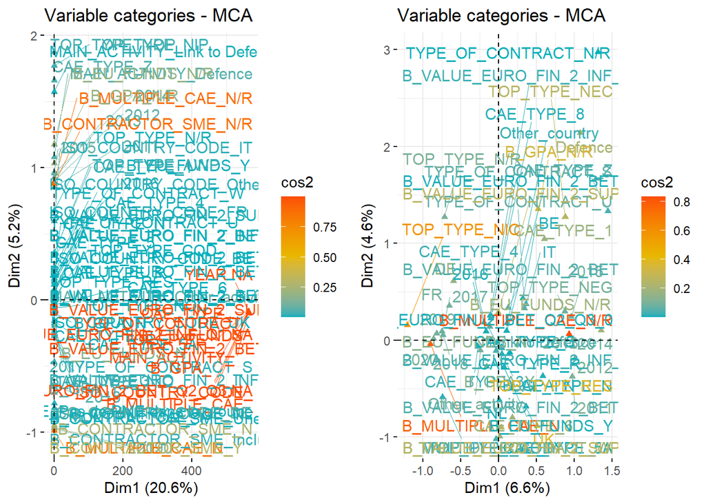

```r
options(ggrepel.max.overlaps = Inf)

#Graphique sur la qualité de représentation des modalités variables, à l'aide du cos2

plot_var_AA=fviz_mca_var(data_TED_CAN_2011_2020_modif_2_MCA,col.var = "cos2",
             gradient.cols = c("#00AFBB", "#E7B800", "#FC4E07"),
             repel = TRUE,
             ggtheme = theme_minimal())

plot_var_AM=fviz_mca_var(data_TED_CN_2011_2020_modif_2_MCA,col.var = "cos2",
             gradient.cols = c("#00AFBB", "#E7B800", "#FC4E07"),
             repel = TRUE,
             ggtheme = theme_minimal(),
             )

plot_grid(plot_var_AA,plot_var_AM)
```

Sur les deux graphiques, on voit les deux premiers axes avec, logiquement, les deux plus grandes valeurs propres, ne résument que 25,8% de l’information concernant la base des avis attribués et 11,2% pour les appels d’offres. Ce qui est très peu même pour une ACM, il a donc été suggéré de faire une CAH des individus avec les nouvelles variables résultantes de l’ACM.

# 4 Classification hiérarchique ascendante :

La CAH va être faite sur les données issues de l’ACM, avec le nombre de dimensions qu’il faut pour avoir une quantité d’information importante. Pour l’analyse, on gardera un nombre d’axes qui conservera environ 80% de l’information. A cette étape là de l’analyse nous utiliserons un échantillon aléatoire équivalent à 2.5% des bases car la CAH n’est pas adaptée pour un grand volume de données.

```r
set.seed(123)

#Déclaration de variable numérique permettant la segmentation du dataframe
a =round(0.025*nrow(data_TED_CAN_2011_2020_modif_2))
b = round(0.025*nrow(data_TED_CN_2011_2020_modif_2))

#On prend un échantillon alétoire de 2.5% de la base
data_TED_CAN_2011_2020_modif_ech = data_TED_CAN_2011_2020_modif_2[sample(nrow(data_TED_CAN_2011_2020_modif_2),a), ]
data_TED_CN_2011_2020_modif_ech = data_TED_CN_2011_2020_modif_2[sample(nrow(data_TED_CN_2011_2020_modif_2), b), ]
```

Pour savoir le nombre de dimension qu’il nous faut pour la CAH, on va exécuter les commandes suivantes:

```r
data_TED_CAN_2011_2020_modif_ech_MCA <- MCA(data_TED_CAN_2011_2020_modif_ech, ncp = 5,graph = FALSE)
data_TED_CN_2011_2020_modif_ech_MCA <- MCA(data_TED_CN_2011_2020_modif_ech, ncp = 5, graph = FALSE)

data_TED_CAN_2011_2020_modif_ech_MCA$eig
```

```
##          eigenvalue percentage of variance cumulative percentage of variance
## dim 1  2.341102e-01           6.688863e+00                          6.688863
## dim 2  1.447839e-01           4.136682e+00                         10.825544
## dim 3  1.335312e-01           3.815178e+00                         14.640723
## dim 4  1.216394e-01           3.475410e+00                         18.116133
## dim 5  1.108604e-01           3.167441e+00                         21.283574
## dim 6  1.058958e-01           3.025593e+00                         24.309167
## dim 7  9.946889e-02           2.841968e+00                         27.151135
## dim 8  9.538815e-02           2.725376e+00                         29.876511
## dim 9  9.373830e-02           2.678237e+00                         32.554748
## dim 10 8.708392e-02           2.488112e+00                         35.042860
## dim 11 8.354034e-02           2.386867e+00                         37.429727
## dim 12 8.186823e-02           2.339092e+00                         39.768819
## dim 13 8.061512e-02           2.303289e+00                         42.072108
## dim 14 7.808222e-02           2.230921e+00                         44.303029
## dim 15 7.749643e-02           2.214184e+00                         46.517213
## dim 16 7.578715e-02           2.165347e+00                         48.682560
## dim 17 7.483330e-02           2.138094e+00                         50.820654
## dim 18 7.437528e-02           2.125008e+00                         52.945662
## dim 19 7.403399e-02           2.115257e+00                         55.060919
## dim 20 7.235427e-02           2.067265e+00                         57.128184
## dim 21 7.188077e-02           2.053736e+00                         59.181920
## dim 22 7.176183e-02           2.050338e+00                         61.232258
## dim 23 7.110367e-02           2.031533e+00                         63.263791
## dim 24 7.080889e-02           2.023111e+00                         65.286902
## dim 25 7.045246e-02           2.012927e+00                         67.299830
## dim 26 6.964567e-02           1.989876e+00                         69.289706
## dim 27 6.896064e-02           1.970304e+00                         71.260010
## dim 28 6.852752e-02           1.957929e+00                         73.217939
## dim 29 6.806708e-02           1.944774e+00                         75.162713
## dim 30 6.719079e-02           1.919737e+00                         77.082450
## dim 31 6.498019e-02           1.856577e+00                         78.939027
## dim 32 6.442770e-02           1.840792e+00                         80.779818
## dim 33 6.252274e-02           1.786364e+00                         82.566182
## dim 34 6.197553e-02           1.770729e+00                         84.336912
## dim 35 5.814432e-02           1.661266e+00                         85.998178
## dim 36 5.647339e-02           1.613525e+00                         87.611703
## dim 37 5.467131e-02           1.562037e+00                         89.173741
## dim 38 5.309536e-02           1.517010e+00                         90.690751
## dim 39 5.135877e-02           1.467394e+00                         92.158145
## dim 40 4.752408e-02           1.357831e+00                         93.515975
## dim 41 4.494458e-02           1.284131e+00                         94.800106
## dim 42 4.041910e-02           1.154831e+00                         95.954938
## dim 43 3.767712e-02           1.076489e+00                         97.031427
## dim 44 3.269660e-02           9.341887e-01                         97.965616
## dim 45 2.983008e-02           8.522880e-01                         98.817904
## dim 46 2.873389e-02           8.209682e-01                         99.638872
## dim 47 1.201938e-02           3.434109e-01                         99.982283
## dim 48 6.200972e-04           1.771706e-02                        100.000000
## dim 49 1.799658e-28           5.141879e-27                        100.000000
```

```r
#ou

data_TED_CN_2011_2020_modif_ech_MCA$eig
```

```
##         eigenvalue percentage of variance cumulative percentage of variance
## dim 1  0.228735663             6.91526423                          6.915264
## dim 2  0.161258872             4.87526822                         11.790532
## dim 3  0.150743457             4.55736032                         16.347893
## dim 4  0.135222068             4.08810903                         20.436002
## dim 5  0.110793639             3.34957512                         23.785577
## dim 6  0.104643341             3.16363588                         26.949213
## dim 7  0.102307730             3.09302438                         30.042237
## dim 8  0.099780788             3.01662847                         33.058866
## dim 9  0.096860821             2.92835039                         35.987216
## dim 10 0.095919757             2.89989962                         38.887116
## dim 11 0.091512997             2.76667200                         41.653788
## dim 12 0.090069892             2.72304325                         44.376831
## dim 13 0.088124476             2.66422834                         47.041059
## dim 14 0.086896312             2.62709780                         49.668157
## dim 15 0.085098065             2.57273219                         52.240889
## dim 16 0.081253513             2.45650154                         54.697391
## dim 17 0.079921718             2.41623798                         57.113629
## dim 18 0.079170133             2.39351564                         59.507144
## dim 19 0.077994713             2.35797971                         61.865124
## dim 20 0.076423235             2.31046989                         64.175594
## dim 21 0.075505528             2.28272527                         66.458319
## dim 22 0.075158300             2.27222767                         68.730547
## dim 23 0.073769106             2.23022880                         70.960776
## dim 24 0.073389838             2.21876254                         73.179538
## dim 25 0.071496137             2.16151113                         75.341049
## dim 26 0.068932770             2.08401398                         77.425063
## dim 27 0.067958098             2.05454716                         79.479611
## dim 28 0.065628671             1.98412263                         81.463733
## dim 29 0.064550806             1.95153599                         83.415269
## dim 30 0.061282244             1.85271901                         85.267988
## dim 31 0.060798174             1.83808434                         87.106073
## dim 32 0.059914693             1.81137443                         88.917447
## dim 33 0.055562020             1.67978201                         90.597229
## dim 34 0.051101252             1.54492157                         92.142151
## dim 35 0.050238634             1.51884243                         93.660993
## dim 36 0.049342910             1.49176239                         95.152755
## dim 37 0.040679215             1.22983673                         96.382592
## dim 38 0.034861594             1.05395516                         97.436547
## dim 39 0.028977133             0.87605285                         98.312600
## dim 40 0.027745321             0.83881202                         99.151412
## dim 41 0.019817090             0.59912134                         99.750533
## dim 42 0.007202918             0.21776263                         99.968296
## dim 43 0.001048668             0.03170392                        100.000000
```

```r
#selon les bases
```

On regarde la colonne “cumulative percentage of variance”, donc nous conserverons 32 dimensions pour la base des avis d’attributions et 27 dimensions pour le jeux de données sur les avis de marchés.

On refait l’ACM en conservant cette fois-ci 32 et 27 dimensions.

```r
data_TED_CAN_2011_2020_modif_ech_MCA <- MCA(data_TED_CAN_2011_2020_modif_ech, ncp = 32,graph = FALSE)
data_TED_CN_2011_2020_modif_ech_MCA <- MCA(data_TED_CN_2011_2020_modif_ech, ncp = 27, graph = FALSE)
```

Le code ci-dessous permet de faire la CAH sur les données issues de l’ACM avec ces visualisations, en indiquant que l’on veut 3 groupes.

```r
#Mise en place de la classification
AA_CAH = HCPC(data_TED_CAN_2011_2020_modif_ech_MCA,max = 3,graph = FALSE)
AM_CAH = HCPC(data_TED_CN_2011_2020_modif_ech_MCA,max = 3,graph = FALSE)
```

```r
#Dendrogrammes
plot_dend_AA = fviz_dend(AA_CAH, show_labels = FALSE)
plot_dend_AM = fviz_dend(AM_CAH, show_labels = FALSE)
#Graphique des clusters
plot_clust_AA = fviz_cluster(AA_CAH, geom = "point", main = "Factor map")
plot_clust_AM = fviz_cluster(AM_CAH, geom = "point", main = "Factor map")
```

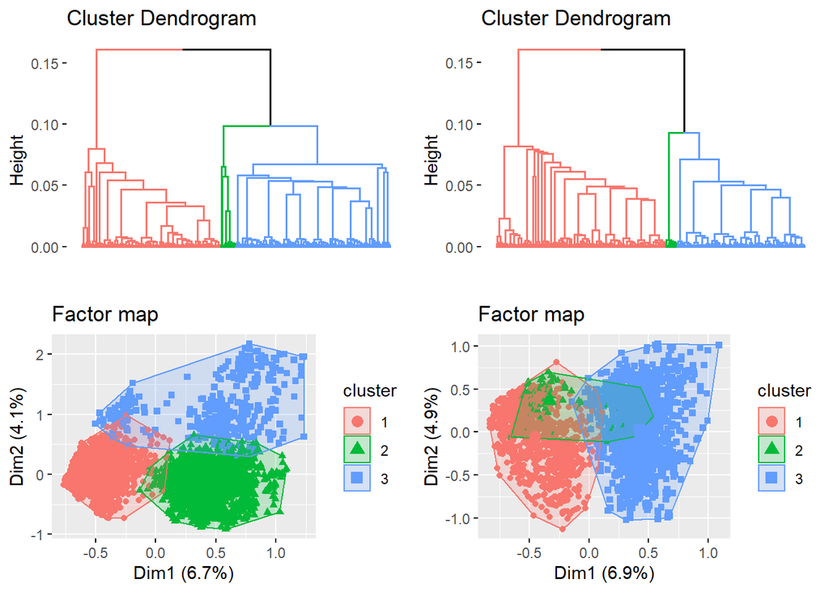

```r
#Plot groupé
plot_grid(plot_dend_AA, plot_dend_AM, plot_clust_AA, plot_clust_AM)
```

# 5 Interprétation des résultats de la CAH :

Les commandes suivantes vont faire une description par variables :

```r
AM_CAH$desc.var$test.chi2
```

```
##                                    p.value df
## YEAR                          0.000000e+00 18
## B_MULTIPLE_CAE                0.000000e+00  4
## TOP_TYPE                      0.000000e+00 10
## B_GPA                        3.110285e-140  4
## ISO_COUNTRY_CODE              2.078334e-51 12
## B_EU_FUNDS                    1.105350e-50  4
## MAIN_ACTIVITY                 8.710082e-23  4
## CAE_TYPE                      3.635364e-16 18
## TYPE_OF_CONTRACT              1.158034e-13  4
## B_VALUE_EURO_FIN_2_BET_Q2_Q3  4.363950e-09  2
## B_VALUE_EURO_FIN_2_SUP_Q3     4.713524e-08  2
## B_VALUE_EURO_FIN_2_INF_Q1     1.512067e-06  2
## B_VALUE_EURO_FIN_2_BET_Q1_Q2  2.930930e-06  2
```

Pour la CAH sur le jeux de données des AM, on voit que les variables YEAR, B_MULTIPLE_CAE, TOP_TYPE, et B_GPA sont celles qui caractérisent le plus la partition en trois classes.

```r
AA_CAH$desc.var$test.chi2
```

```
##                                    p.value df
## YEAR                          0.000000e+00 18
## B_MULTIPLE_CAE                0.000000e+00  4
## CAE_TYPE                      0.000000e+00 16
## MAIN_ACTIVITY                 0.000000e+00  4
## TOP_TYPE                      0.000000e+00 14
## B_CONTRACTOR_SME              0.000000e+00 10
## B_GPA                        4.925496e-204  4
## B_EU_FUNDS                   2.179039e-165  4
## ISO_COUNTRY_CODE             1.009058e-105 12
## TYPE_OF_CONTRACT              1.691143e-29  4
## B_VALUE_EURO_FIN_2_INF_Q1     2.998536e-18  2
## B_VALUE_EURO_FIN_2_SUP_Q3     4.322247e-12  2
## B_VALUE_EURO_FIN_2_BET_Q2_Q3  4.512082e-05  2
```

Pour la CAH sur le jeux de données des AA, on voit que les variables YEAR, B_MULTIPLE_CAE, CAE_TYPE, MAIN_ACTIVITY, TOP_TYPE, et B_CONTRACTOR_SME sont celles qui caractérisent le plus la partition en trois classes.

La partie la plus pertinente est la description par modalités qui va se faire avec les commandes suivantes :

```r
AM_CAH$desc.var$category
```

```
## $`1`
##                                                                Cla/Mod
## B_MULTIPLE_CAE=B_MULTIPLE_CAE_N                              92.559787
## TOP_TYPE=TOP_TYPE_NIC                                       100.000000
## YEAR=2020                                                    91.519435
## YEAR=2019                                                    86.617100
## YEAR=2018                                                    83.443709
## YEAR=2017                                                    81.159420
## B_EU_FUNDS=B_EU_FUNDS_N                                      50.218553
## B_GPA=B_GPA_Y                                                54.665630
## MAIN_ACTIVITY=Other_activity                                 53.093525
## B_MULTIPLE_CAE=B_MULTIPLE_CAE_Y                             100.000000
## ISO_COUNTRY_CODE=DE                                          61.797753
## ISO_COUNTRY_CODE=FR                                          57.771261
## B_VALUE_EURO_FIN_2_SUP_Q3=B_VALUE_EURO_FIN_2_SUP_Q3_1        53.344768
## TYPE_OF_CONTRACT=S                                           48.041775
## B_VALUE_EURO_FIN_2_INF_Q1=B_VALUE_EURO_FIN_2_INF_Q1_1        51.074380
## B_VALUE_EURO_FIN_2_BET_Q2_Q3=B_VALUE_EURO_FIN_2_BET_Q2_Q3_0  46.541555
## CAE_TYPE=CAE_TYPE_3                                          49.740035
## CAE_TYPE=CAE_TYPE_4                                          49.509804
## B_VALUE_EURO_FIN_2_BET_Q1_Q2=B_VALUE_EURO_FIN_2_BET_Q1_Q2_0  46.237141
## YEAR=2016                                                    50.996016
## B_VALUE_EURO_FIN_2_BET_Q1_Q2=B_VALUE_EURO_FIN_2_BET_Q1_Q2_1  40.947547
## ISO_COUNTRY_CODE=BE                                          30.000000
## B_VALUE_EURO_FIN_2_BET_Q2_Q3=B_VALUE_EURO_FIN_2_BET_Q2_Q3_1  39.790576
## B_VALUE_EURO_FIN_2_INF_Q1=B_VALUE_EURO_FIN_2_INF_Q1_0        42.935079
## B_VALUE_EURO_FIN_2_SUP_Q3=B_VALUE_EURO_FIN_2_SUP_Q3_0        42.318059
## CAE_TYPE=CAE_TYPE_Z                                           0.000000
## CAE_TYPE=CAE_TYPE_1                                          30.830040
## MAIN_ACTIVITY=Defence                                        15.714286
## TYPE_OF_CONTRACT=U                                           34.381139
## ISO_COUNTRY_CODE=IT                                          24.691358
## ISO_COUNTRY_CODE=UK                                          33.432836
## MAIN_ACTIVITY=Link to Defence                                35.480573
## TOP_TYPE=TOP_TYPE_RES                                        35.044248
## TOP_TYPE=TOP_TYPE_N/R                                         0.000000
## YEAR=2015                                                     0.000000
## YEAR=2013                                                     0.000000
## YEAR=2014                                                     0.000000
## YEAR=2012                                                     0.000000
```

[output cut: 522 more lines]

```
## TYPE_OF_CONTRACT=S                                           -5.074493
## CAE_TYPE=CAE_TYPE_3                                          -5.227997
## B_GPA=B_GPA_Y                                                -6.607713
## ISO_COUNTRY_CODE=DE                                          -6.852628
## B_MULTIPLE_CAE=B_MULTIPLE_CAE_Y                              -8.350382
## ISO_COUNTRY_CODE=FR                                          -8.583832
## MAIN_ACTIVITY=Other_activity                                 -9.743802
## TOP_TYPE=TOP_TYPE_N/R                                       -11.432278
## B_EU_FUNDS=B_EU_FUNDS_N                                     -12.883702
## YEAR=2017                                                   -14.411626
## YEAR=2018                                                   -15.486614
## YEAR=2019                                                   -17.191117
## YEAR=2020                                                   -19.122264
## TOP_TYPE=TOP_TYPE_NIC                                       -35.023498
## B_MULTIPLE_CAE=B_MULTIPLE_CAE_N                                   -Inf
```

**Pour les AM, ce qu’on peut en tirer des résultats ci dessus sont que :**

- Dans la première classe, la plupart des appels d’offres datent de 2017 à 2020, ils sont issus d’une seule CAE. La procédure utilisée pour ce groupe est la procédure négociée avec mise en compétition (NIC).
- Dans le deuxième groupe, la plupart des avis de marchés ont une procédure qui n’est pas renseignée, et il n’est pas renseigné si ces avis sont couverts par l’accord sur les marchés publics. La plupart des avis sont promulgués par une seule CAE, généralement française de type 3 (autorité régionale ou locale).
- Dans le troisième cluster, il y a plus d’appels d’offres de 2011 à 2015 avec une négociation avec appel à la compétition, on ne sait pas si oui ou non il ya eu un financement de l’UE et s’il y a eu une ou plusieurs CAE.

```r
AA_CAH$desc.var$category
```

```
## $`1`
##                                                                 Cla/Mod
## B_CONTRACTOR_SME=B_CONTRACTOR_SME_Y                         98.07692308
## B_CONTRACTOR_SME=B_CONTRACTOR_SME_N                         97.91542585
## B_MULTIPLE_CAE=B_MULTIPLE_CAE_N                             98.07799443
## YEAR=2020                                                   93.96771453
## YEAR=2019                                                   93.82591093
## B_EU_FUNDS=B_EU_FUNDS_N                                     52.36751333
## YEAR=2018                                                   79.44915254
## MAIN_ACTIVITY=Other_activity                                47.88844622
## ISO_COUNTRY_CODE=DE                                         68.18580193
## YEAR=2017                                                   70.56856187
## B_CONTRACTOR_SME=B_CONTRACTOR_SME_Inclue plusieurs PME      98.84393064
## B_GPA=B_GPA_Y                                               55.11186633
## B_CONTRACTOR_SME=B_CONTRACTOR_SME_Pas de PME dans le groupe 98.13084112
## B_MULTIPLE_CAE=B_MULTIPLE_CAE_Y                             97.02970297
## TOP_TYPE=TOP_TYPE_NIC                                       54.64409722
## CAE_TYPE=CAE_TYPE_3                                         54.40539239
## ISO_COUNTRY_CODE=NL                                         71.84115523
## B_CONTRACTOR_SME=B_CONTRACTOR_SME_Une PME dans le groupe    95.00000000
## TYPE_OF_CONTRACT=S                                          48.75610840
## B_VALUE_EURO_FIN_2_INF_Q1=B_VALUE_EURO_FIN_2_INF_Q1_1       51.50024594
## B_VALUE_EURO_FIN_2_BET_Q2_Q3=B_VALUE_EURO_FIN_2_BET_Q2_Q3_0 46.97580645
## CAE_TYPE=CAE_TYPE_8                                         50.90337785
## CAE_TYPE=CAE_TYPE_6                                         48.34254144
## B_GPA=B_GPA_N                                               47.15025907
## TOP_TYPE=TOP_TYPE_N/R                                       34.00000000
## CAE_TYPE=CAE_TYPE_N                                         35.94771242
## TYPE_OF_CONTRACT=U                                          43.13232831
## B_VALUE_EURO_FIN_2_BET_Q2_Q3=B_VALUE_EURO_FIN_2_BET_Q2_Q3_1 41.65824065
## MAIN_ACTIVITY=Link to Defence                                0.00000000
## B_EU_FUNDS=B_EU_FUNDS_Y                                     35.98484848
## ISO_COUNTRY_CODE=FR                                         40.26578073
## TYPE_OF_CONTRACT=W                                          37.98076923
## CAE_TYPE=CAE_TYPE_4                                         37.79399838
## B_VALUE_EURO_FIN_2_INF_Q1=B_VALUE_EURO_FIN_2_INF_Q1_0       43.63235543
## TOP_TYPE=TOP_TYPE_NIP                                        0.00000000
## ISO_COUNTRY_CODE=IT                                         27.72277228
## CAE_TYPE=CAE_TYPE_1                                         34.04878049
## YEAR=2016                                                   30.33033033
```

[output cut: 685 more lines]

```
## B_EU_FUNDS=B_EU_FUNDS_Y                                      -6.444108
## TOP_TYPE=TOP_TYPE_AWP                                        -6.818566
## B_VALUE_EURO_FIN_2_SUP_Q3=B_VALUE_EURO_FIN_2_SUP_Q3_0        -6.880429
## TYPE_OF_CONTRACT=W                                           -6.900413
## B_GPA=B_GPA_N                                                -7.013393
## B_CONTRACTOR_SME=B_CONTRACTOR_SME_N                          -7.240016
## B_CONTRACTOR_SME=B_CONTRACTOR_SME_Y                          -7.625679
## B_VALUE_EURO_FIN_2_INF_Q1=B_VALUE_EURO_FIN_2_INF_Q1_1        -8.461560
## CAE_TYPE=CAE_TYPE_4                                         -11.036009
## B_GPA=B_GPA_Y                                               -11.664716
## CAE_TYPE=CAE_TYPE_6                                         -12.346151
## TOP_TYPE=TOP_TYPE_NIC                                       -12.791561
## B_MULTIPLE_CAE=B_MULTIPLE_CAE_N                             -12.896568
## CAE_TYPE=CAE_TYPE_3                                         -15.879525
## MAIN_ACTIVITY=Other_activity                                      -Inf
```

**Quant aux AA, ce qu’on peut en tirer des résultats ci dessus sont que :**

- Pour le premier groupe, on remarque que la majorité des avis attribués de 2019 et de 2020 ont été initié par une seule entité adjudicatrice. Il y a autant de gagnants du côté des PME que des non-PME.
- En ce qui concerne la deuxième classe, la majorité des avis attribués datent de 2011 à 2015 on ne sait pas si la passation de marché s’est faite auprès de PME ou non, si l’avis est initié par de multiples entités adjudicatrices ou bien si l’avis a été financé par l’UE.
- Les avis attribués qui appartiennent aux troisièmes clusters sont promulgués par une CAE de type 1 (ministères ou toutes autres autorités nationales ou fédérales) qui ont pour activité principale la Défense, et la procédure négociée sans mise en concurrence (NOP) a été privilégiée.